# FordGo Dataset Slides

### by Mercy Solomon

## Investigation Overview

> In this investigation, I wanted to find answers to a couple of questions, some of which include:
> - What is the gender distribution of the users?
> - Is there any relationship between gender and bike share for all trips?
> - What is the age distribution of the users?
> - What day of the week is the service often used?

## Dataset Overview

> This dataset includes information about individual rides made in a bike-sharing system covering the greater San Francisco Bay area for the duration of Febraury 2019.

## Gender distribution of the users

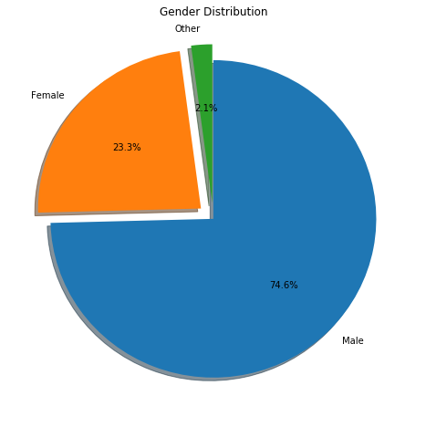

This is a pretty explanatory chart showing that Males make up 74.6% of users while Females make up 23.3% with Other taking up the remaining 2.1%. The ride share platform definitely has more males as users.

## Relationship between gender and bike share for all trip

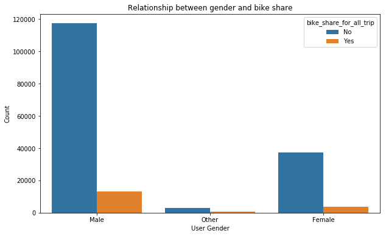

## Age distribution of the users

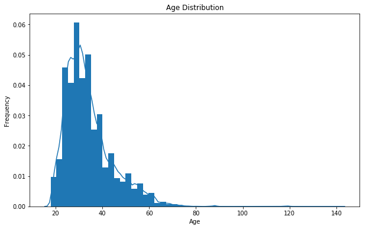

The rideshare app has a fair number of young users with the mean being 34 and most users falling between the age(s) 20-40.

## Distribution of daily rides

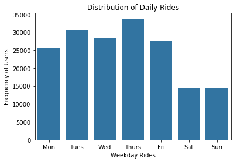